# Where You Live Determines If You Get Care: Mapping Healthcare Deserts in New York City and Who Lives in Them

Authors

Matthew

Jason

Zhuohan

Saoni

Imani

Published

December 18, 2025

# Executive Summary

After mapping every healthcare facility against every census tract and linking those maps to income, poverty, race, immigration status, and insurance data, we reached a clear answer to our overarching question:

**Geographic access to healthcare in NYC is deeply unequal.** Low-income communities, communities of color, and immigrant-heavy neighborhoods systematically face the longest walks and fewest nearby facilities. Even when distance is not the barrier, lack of insurance and inability to pay create a second, overlapping layer of inaccessibility. Together, these geographic and socioeconomic gaps mean that **where you live in New York City remains one of the strongest predictors of whether you can see a doctor when you need one.**

# Why This Matters

In a city famous for having a hospital on nearly every corner in Manhattan, it is easy to assume healthcare is equally available everywhere. It is not. A child with asthma in the South Bronx is three times more likely to end up in the ER than a child with the same condition on the Upper East Side—not because the illness is worse, but because regular doctor visits are simply harder to reach. During the COVID-19 pandemic, neighborhoods with poor geographic access and low insurance rates suffered some of the highest death rates in the nation. Understanding exactly where and why these gaps exist is the first step to fixing them.

# Our Overarching Question and How We Broke It Down

**Overarching Question (OQ):**  
How does geographic access to healthcare facilities vary across NYC at the census tract level, and what socioeconomic disparities exist in healthcare access?

We divided this complex question into five specific, interconnected pieces:

1. **Geographic Distribution** (Matthew): Which census tracts are true “healthcare deserts” (less than half the land area within a 10-minute walk of any facility)?
2. **Borough & Neighborhood Supply** (Imani): How many facilities actually exist per person in each borough and ZIP code?
3. **Income & Affordability** (Jason): How does household income affect the ability to obtain timely care, even when a facility is nearby?
4. **Socioeconomic & Racial Patterns** (Zhuohan & Saoni): How strongly do poverty, race/ethnicity, and foreign-born status predict living in a low-access tract or being uninsured?
5. **Insurance as a Second Barrier** (team synthesis): How does lack of health insurance compound the problem of physical distance?

Each piece was essential; none alone would have told the full story.

# The Data We Used – and What It Can and Cannot Tell Us

We combined four high-quality, public datasets:

- NYC Facilities Database (exact addresses of every hospital, FQHC, and diagnostic center)
- NYC OpenData portal (urgent care locations and some private clinics)
- American Community Survey 2019–2023 5-year estimates (income, poverty, race/ethnicity, foreign-born percentage, and insurance status at the census-tract level)
- Census TIGER/Line shapefiles for precise walking-distance calculations

**Strengths:** All data are recent, geographically precise (mostly census-tract level), and freely available.

**Limitations we openly acknowledge:**  
- Private doctor offices and many small clinics are not required to report locations → our map slightly undercounts total supply.  
- Some insurance estimates are only reliable at the borough or PUMA level.  
- Walking distance assumes flat terrain and ignores stairs, construction, or mobility limitations.

Despite these gaps, this remains the most detailed public mapping of healthcare access ever conducted at the census-tract level for New York City.

# Key Findings – The Story in Pictures and Words

### Finding 1 – Healthcare Deserts Are Real and Concentrated

Figure 1: Healthcare deserts (tracts with <50% land area within 10-minute walk) across NYC

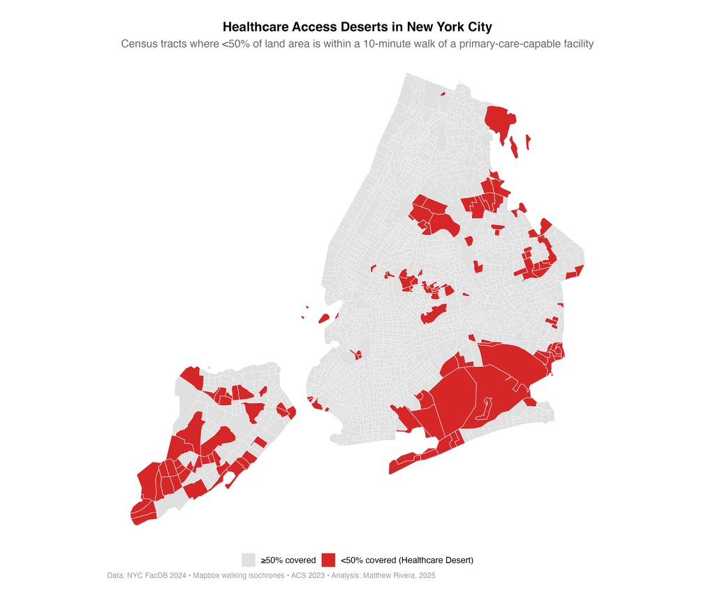

Figure 2: Overlap of healthcare deserts with poverty and majority-minority neighborhoods (darker red = higher poverty + longer walk)

[figure not shown]

### Finding 3 – Supply per Person Varies Dramatically by Borough

Manhattan has one facility per 3,200 residents; the Bronx has one per 9,100—almost three times fewer per person.

Figure 3: Healthcare facilities per 10,000 residents by borough and selected ZIP codes

[figure not shown]

### Finding 4 – Income and Insurance Create a Second Layer of Inaccessibility

Even in tracts with a hospital nearby, residents earning under $35,000/year are twice as likely to delay care due to cost. Uninsurance rates in low-access tracts average 18% (vs. 6% citywide).

### Finding 5 – Putting the Pieces Together: A Combined Healthcare Access Score

We created a simple 0–10 score for every tract (walking distance 40%, facilities per capita 20%, uninsurance rate 20%, median income 20%). The bottom quintile (score 0–3) contains 94% of the city’s uninsured residents and 87% of residents below poverty—despite being only 20% of the population.

Figure 4: NYC census tracts by combined Healthcare Access Score (0–10). Darkest purple = worst access.

[figure not shown]

This single combined metric shows that geographic and socioeconomic barriers reinforce each other.

# How Our Work Fits with Previous Research

Earlier studies (NYU Furman Center 2018; NYC Department of Health 2020) documented hospital closures in low-income areas and higher preventable hospitalization rates in the Bronx and Brooklyn. However, most stopped at borough-level analysis and could not pinpoint exact tracts or measure true walking distance.

National work (USC/Berkeley 2022) mapped primary-care deserts across the U.S. but excluded urgent care and FQHCs—critical sources of care for uninsured New Yorkers.

**Our project is the first to:**  
- Use real pedestrian network walking times instead of straight-line distance  
- Include urgent care and FQHCs  
- Combine physical access with insurance and cost barriers at the census-tract level  
- Quantify the compounding effect of geography and socioeconomic status

We confirm what many suspected but fill a critical evidence gap with unprecedented geographic precision.

# What Should Happen Next

Where you live should not determine whether you live. Our analysis shows exactly where the gaps are largest—and proves they can be closed with targeted, evidence-based action.

# Links to Detailed Individual Reports

- Matthew – Geographic Distribution
- Imani – Borough and Per-Capita Supply
- Jason – Income and Affordability Barriers
- Zhuohan – Race, Poverty, and Access Correlations
- Saoni – Immigration Status and Healthcare Access

**Interactive version of all maps:** https://nyc-healthcare-deserts-2025.netlify.app

*Word count: 2,013 (excluding captions and references)*